# 431 Class 07

Thomas E. Love, Ph.D.

2025-09-23

## Today’s Agenda

- New Data: Ohio’s 88 Counties
- Comparing Two Samples
  - How should we interpret an uncertainty interval?
- Comparing More than Two Independent Samples
  - Analysis of Variance (ANOVA)
  - Using Regression to Develop an ANOVA model

## Load packages and set theme

```r
library(janitor)
library(patchwork)
library(readxl)
library(knitr)
library(kableExtra)
library(MKinfer)
library(rstanarm)
library(car)
library(ggdist)
library(easystats)
library(tidyverse)

theme_set(theme_bw())
knitr::opts_chunk$set(comment = NA)

source("c07/data/Love-431.R") # for the lovedist() function
```

## `ohio_2019.xlsx` codebook

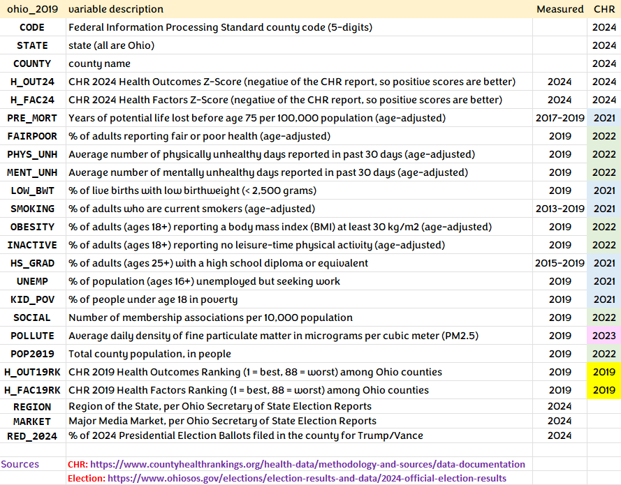

## The `ohio_2019.xlsx` file

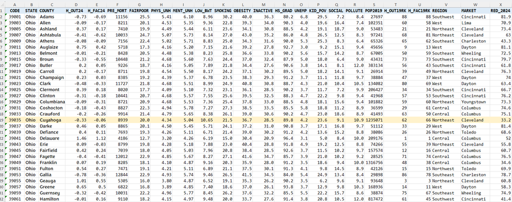

## Data Ingest

```r
oh19 <- read_xlsx("c07/data/ohio_2019.xlsx") |>
  janitor::clean_names()

oh19
```

```
# A tibble: 88 × 24
   code  state county    h_out24 h_fac24 pre_mort fairpoor phys_unh ment_unh
   <chr> <chr> <chr>       <dbl>   <dbl>    <dbl>    <dbl>    <dbl>    <dbl>
 1 39001 Ohio  Adams       -0.73   -0.69    11156     25.5     5.41     6.1
 2 39003 Ohio  Allen       -0.09   -0.17     8211     20.1     4.53     5.35
 3 39005 Ohio  Ashland      0.37    0.17     7410     19.9     4.49     5.44
 4 39007 Ohio  Ashtabula   -0.41   -0.62    10033     24.7     5.07     5.73
 5 39009 Ohio  Athens      -0.08   -0.09     7156     22.4     5.02     5.71
 6 39011 Ohio  Auglaize     0.75    0.42     5718     17.3     4.16     5.2
 7 39013 Ohio  Belmont     -0.01   -0.21     8428     20.5     4.48     5.38
 8 39015 Ohio  Brown       -0.33   -0.55    10448     21.2     4.68     5.6
 9 39017 Ohio  Butler       0.2     0.05     9226     18.7     4.16     5.05
10 39019 Ohio  Carroll      0.2    -0.17     8711     19.8     4.54     5.5
# ℹ 78 more rows
# ℹ 15 more variables: low_bwt <dbl>, smoking <dbl>, obesity <dbl>,
#   inactive <dbl>, hs_grad <dbl>, unemp <dbl>, kid_pov <dbl>, social <dbl>,
#   pollute <dbl>, pop2019 <dbl>, h_out19rk <dbl>, h_fac19rk <dbl>,
#   region <chr>, market <chr>, red_2024 <dbl>
```

## Selecting Variables for Today’s Class

```r
ohio_7 <- oh19 |>
  select(county, h_out24, red_2024, inactive,
         h_fac19rk, h_out19rk, social)

ohio_7
```

```
# A tibble: 88 × 7
   county    h_out24 red_2024 inactive h_fac19rk h_out19rk social
   <chr>       <dbl>    <dbl>    <dbl>     <dbl>     <dbl>  <dbl>
 1 Adams       -0.73     81.9     36.3        88        88    7.2
 2 Allen       -0.09     70.9     34          58        60   16.4
 3 Ashland      0.37     73.4     30.8        21        21   18.7
 4 Ashtabula   -0.41     63       35.2        81        68   12.5
 5 Athens      -0.08     43.3     31.6        62        65    8.3
 6 Auglaize     0.75     81.1     27.8        13         9   15.1
 7 Belmont     -0.01     72.5     33.8        59        50   14.2
 8 Brown       -0.33     79.7     32.4        73        73    6.4
 9 Butler       0.2      61.8     27.6        43        56    8.1
10 Carroll      0.2      76.3     30.2        49        39   14.1
# ℹ 78 more rows
```

## Variables Selected: `ohio_7`

[output not shown]

## `data_codebook()` result

```r
data_codebook(ohio_7)
```

```
ohio_7 (88 rows and 7 variables, 7 shown)

ID | Name      | Type      | Missings |        Values |        N
---+-----------+-----------+----------+---------------+---------
1  | county    | character | 0 (0.0%) |         Adams | 1 (1.1%)
   |           |           |          |         Allen | 1 (1.1%)
   |           |           |          |       Ashland | 1 (1.1%)
   |           |           |          |     Ashtabula | 1 (1.1%)
   |           |           |          |        Athens | 1 (1.1%)
   |           |           |          |      Auglaize | 1 (1.1%)
   |           |           |          |       Belmont | 1 (1.1%)
   |           |           |          |         Brown | 1 (1.1%)
   |           |           |          |        Butler | 1 (1.1%)
   |           |           |          |       Carroll | 1 (1.1%)
   |           |           |          |         (...) |
---+-----------+-----------+----------+---------------+---------
2  | h_out24   | numeric   | 0 (0.0%) | [-1.21, 1.46] |       88
---+-----------+-----------+----------+---------------+---------
3  | red_2024  | numeric   | 0 (0.0%) |    [33.2, 83] |       88
---+-----------+-----------+----------+---------------+---------
4  | inactive  | numeric   | 0 (0.0%) |  [20.9, 39.1] |       88
---+-----------+-----------+----------+---------------+---------
5  | h_fac19rk | numeric   | 0 (0.0%) |       [1, 88] |       88
---+-----------+-----------+----------+---------------+---------
6  | h_out19rk | numeric   | 0 (0.0%) |       [1, 88] |       88
---+-----------+-----------+----------+---------------+---------
7  | social    | numeric   | 0 (0.0%) |   [3.8, 19.3] |       88
----------------------------------------------------------------
```

## Data Management for `ohio_7`

1. Store ranks (1 = best, 88 = worst) of counties based on `h_out24` in `h_out24rk`.

```r
ohio_7 <- ohio_7 |>
  mutate(h_out24rk = 89-row_number(h_out24))

ohio_7 |> select(county, h_out24, h_out24rk) |>
  filter(county %in% c("Cuyahoga", "Delaware", "Geauga", "Scioto"))
```

```
# A tibble: 4 × 3
  county   h_out24 h_out24rk
  <chr>      <dbl>     <dbl>
1 Cuyahoga   -0.33        70
2 Delaware    1.46         1
3 Geauga      1.01         6
4 Scioto     -1.21        88
```

## Data Management for `ohio_7`

2. Create two groups in `sedentary` to reflect top third and bottom third of counties by `inactive`

```r
ohio_7 <- ohio_7 |>
  mutate(sedentary = case_when(
    inactive >= quantile(inactive, 0.67) ~ "More",
    inactive < quantile(inactive, 0.33) ~ "Less"))

ohio_7 |> tabyl(sedentary) |> adorn_pct_formatting()
```

```
 sedentary  n percent valid_percent
      Less 29   33.0%         50.0%
      More 29   33.0%         50.0%
      <NA> 30   34.1%             -
```

## Data Management for `ohio_7`

3. Place into `hfactor` four groups of equal size derived from the `h_fac19rk` data.

```r
ohio_7 <- ohio_7 |>
  mutate(hfactor = case_when(
    h_fac19rk <= 22 ~ "Best",
    h_fac19rk > 22 & h_fac19rk <= 44 ~ "High",
    h_fac19rk > 44 & h_fac19rk <= 66 ~ "Low",
    h_fac19rk > 66 ~ "Worst"))

ohio_7 |> group_by(hfactor) |> reframe(lovedist(h_fac19rk))
```

```
# A tibble: 4 × 11
  hfactor     n  miss  mean    sd   med   mad   min   q25   q75   max
  <chr>   <int> <int> <dbl> <dbl> <dbl> <dbl> <dbl> <dbl> <dbl> <dbl>
1 Best       22     0  11.5  6.49  11.5  8.15     1  6.25  16.8    22
2 High       22     0  33.5  6.49  33.5  8.15    23 28.2   38.8    44
3 Low        22     0  55.5  6.49  55.5  8.15    45 50.2   60.8    66
4 Worst      22     0  77.5  6.49  77.5  8.15    67 72.2   82.8    88
```

## Data Management for `ohio_7`

4. Place into `soc_grp` three groups of (approximately) equal size derived from the `social` data.

```r
ohio_7 <- ohio_7 |>
  mutate(soc_gp = cut_number(social, n = 3))

ohio_7 |> tabyl(soc_gp) |> adorn_pct_formatting()
```

```
      soc_gp  n percent
  [3.8,10.2] 30   34.1%
 (10.2,12.9] 29   33.0%
 (12.9,19.3] 29   33.0%
```

```r
ohio_7 <- ohio_7 |>
  mutate(soc_gp = fct_recode(factor(soc_gp),
                             "Small" = "[3.8,10.2]",
                             "Medium" = "(10.2,12.9]",
                             "Large" = "(12.9,19.3]"))
```

## One of Today’s Outcomes

- **red_2024** = % of 2024 Presidential Election Ballots for Trump/Vance

```r
ohio_7 |> reframe(lovedist(red_2024))
```

```
# A tibble: 1 × 10
      n  miss  mean    sd   med   mad   min   q25   q75   max
  <int> <int> <dbl> <dbl> <dbl> <dbl> <dbl> <dbl> <dbl> <dbl>
1    88     0  68.3  11.2    71  9.41  33.2  62.7  76.2    83
```

```r
ohio_7 |> select(county, red_2024) |>
  filter(county %in% c("Cuyahoga", "Putnam"))
```

```
# A tibble: 2 × 2
  county   red_2024
  <chr>       <dbl>
1 Cuyahoga     33.2
2 Putnam       83
```

## Another of Today’s Outcomes

- **h_out24** (outcomes) = quantity that describes the county’s premature death and quality of life results, weighted equally and standardized (z scores), in 2024.
  - Higher (more positive) values indicate better outcomes in this county.

```r
ohio_7 |> reframe(lovedist(h_out24))
```

```
# A tibble: 1 × 10
      n  miss   mean    sd   med   mad   min   q25   q75   max
  <int> <int>  <dbl> <dbl> <dbl> <dbl> <dbl> <dbl> <dbl> <dbl>
1    88     0 0.0915 0.533  0.16 0.482 -1.21 -0.31 0.425  1.46
```

## Create Factors, Drop Unused Levels

```r
ohio_7 <- ohio_7 |>
  mutate(across(where(is.character), as_factor)) |>
  mutate(county = as.character(county)) |>
  droplevels()

glimpse(ohio_7)
```

```
Rows: 88
Columns: 11
$ county    <chr> "Adams", "Allen", "Ashland", "Ashtabula", "Athens", "Auglaiz…
$ h_out24   <dbl> -0.73, -0.09, 0.37, -0.41, -0.08, 0.75, -0.01, -0.33, 0.20, …
$ red_2024  <dbl> 81.9, 70.9, 73.4, 63.0, 43.3, 81.1, 72.5, 79.7, 61.8, 76.3, …
$ inactive  <dbl> 36.3, 34.0, 30.8, 35.2, 31.6, 27.8, 33.8, 32.4, 27.6, 30.2, …
$ h_fac19rk <dbl> 88, 58, 21, 81, 62, 13, 59, 73, 43, 49, 37, 69, 34, 53, 60, …
$ h_out19rk <dbl> 88, 60, 21, 68, 65, 9, 50, 73, 56, 39, 47, 80, 34, 57, 59, 2…
$ social    <dbl> 7.2, 16.4, 18.7, 12.5, 8.3, 15.1, 14.2, 6.4, 8.1, 14.1, 11.8…
$ h_out24rk <dbl> 82, 57, 30, 74, 55, 8, 53, 71, 41, 40, 38, 78, 28, 67, 56, 6…
$ sedentary <fct> More, More, NA, More, NA, Less, More, More, Less, NA, Less, …
$ hfactor   <fct> Worst, Low, Best, Worst, Low, Best, Low, Worst, High, Low, H…
$ soc_gp    <fct> Small, Large, Large, Medium, Small, Large, Large, Small, Sma…
```

# Research Question 1

## Question 1

What is the difference in the average % of Republican presidential election ballots in 2024 between the most sedentary and least sedentary thirds of Ohio counties (as measured in 2019)?

Key variables:

- `red_2024` (numeric)
- `sedentary` (factor with 2 levels)

Comparing Two Means: Paired or Independent Samples?

## DTDP. What’s wrong here?

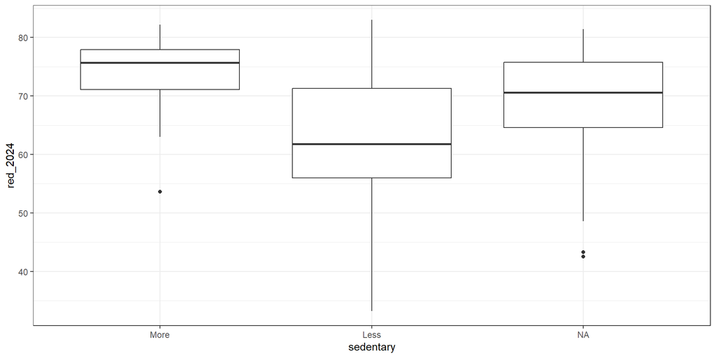

```r
ggplot(ohio_7, aes(x = sedentary, y = red_2024)) +
  geom_boxplot()
```

## % Republican by Sedentary

```r
ques1 <- ohio_7 |> filter(complete.cases(sedentary))

ggplot(ques1, aes(x = sedentary, y = red_2024)) +
  geom_violin(aes(fill = sedentary)) +
  geom_boxplot(width = 0.2, fill = "white", notch = TRUE) +
  stat_summary(fun = mean, geom = "point",
               size = 2, col = "red") +
  scale_fill_viridis_d(option = "plasma", alpha = 0.4) +
  guides(fill = "none") +
  labs(y = "% of votes for Republicans in 2024",
       title = "Two Sample Comparison") +
  coord_flip()
```

## % Republican by Sedentary

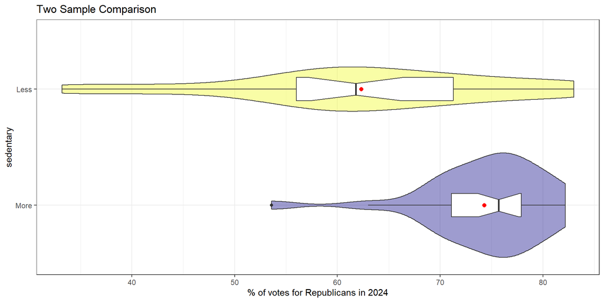

## Summarizing the Sample

Numerical Summary with `lovedist()` from `Love-431.R`.

```r
ques1 |> group_by(sedentary) |>
  reframe(lovedist(red_2024))
```

```
# A tibble: 2 × 11
  sedentary     n  miss  mean    sd   med   mad   min   q25   q75   max
  <fct>     <int> <int> <dbl> <dbl> <dbl> <dbl> <dbl> <dbl> <dbl> <dbl>
1 More         29     0  74.3  5.95  75.7  4.45  53.6  71.1  77.9  82.2
2 Less         29     0  62.3 13.0   61.8 11.7   33.2  56    71.3  83
```

- Which group has the larger sample mean `red_2024`?
- Can we reasonably pool standard deviations?
- What can we say about skew in each group?

## Q1: Comparison with t-test/OLS

What conclusions can we draw from this pooled t approach?

```r
m1a <- t.test(red_2024 ~ sedentary, conf.level = 0.95,
              var.equal = TRUE, data = ques1)
model_parameters(m1a)
```

```
Two Sample t-test

Parameter |     Group | sedentary = More | sedentary = Less | Difference
------------------------------------------------------------------------
red_2024  | sedentary |            74.30 |            62.31 |      11.99

Parameter |        95% CI | t(56) |      p
------------------------------------------
red_2024  | [6.65, 17.32] |  4.50 | < .001

Alternative hypothesis: true difference in means between group More and group Less is not equal to 0
```

## Q1: Comparison with t-test/OLS

Are these the same results?

```r
m1b <- lm(red_2024 ~ sedentary, data = ques1)
model_parameters(m1b, conf.level = 0.95)
```

```
Parameter        | Coefficient |   SE |          95% CI | t(56) |      p
------------------------------------------------------------------------
(Intercept)      |       74.30 | 1.88 | [ 70.53, 78.07] | 39.48 | < .001
sedentary [Less] |      -11.99 | 2.66 | [-17.32, -6.65] | -4.50 | < .001
```

## Q1: Comparison with Welch’s t

```r
m1c <- t.test(red_2024 ~ sedentary, conf.level = 0.95,
              var.equal = FALSE, data = ques1)
model_parameters(m1c)
```

```
Welch Two Sample t-test

Parameter |     Group | sedentary = More | sedentary = Less | Difference
------------------------------------------------------------------------
red_2024  | sedentary |            74.30 |            62.31 |      11.99

Parameter |        95% CI | t(39.17) |      p
---------------------------------------------
red_2024  | [6.60, 17.37] |     4.50 | < .001

Alternative hypothesis: true difference in means between group More and group Less is not equal to 0
```

## Q1: Comparison with bootstrap

```r
set.seed(43107)
boot.t.test(red_2024 ~ sedentary, data = ques1, R = 2000,
            var.equal = FALSE, conf.level = 0.95)
```

```
    Bootstrap Welch Two Sample t-test

data:  red_2024 by sedentary
number of bootstrap samples:  2000
bootstrap p-value < 5e-04
bootstrap difference of means (SE) = 12.04928 (2.606542)
95 percent bootstrap percentile confidence interval:
  6.694914 17.120948

Results without bootstrap:
t = 4.5035, df = 39.173, p-value = 5.87e-05
alternative hypothesis: true difference in means is not equal to 0
95 percent confidence interval:
  6.603544 17.368870
sample estimates:
mean in group More mean in group Less
          74.29655           62.31034
```

## Q1 estimates

| Approach | Estimate | 95% confidence interval |
| --- | --- | --- |
| Pooled t | 11.99 | (6.65, 17.32) |
| Welch t | 11.99 | (6.60, 17.37) |
| Bootstrap | 12.05 | (6.69, 17.12) |

- Which of these should we choose?
  - Or does it not matter much?
- Once we’ve made a choice, how can we describe the result properly?

## Selecting the OLS/pooled t (1/2)

- Point Estimate: 11.99
- 95% pooled t Confidence Interval: (6.65, 17.32)

Our best point estimate for the true difference (More Sedentary - Less Sedentary) is 11.99 percentage points in the % of Republican voters in 2024.

The confidence interval reflects imprecision in the population estimate, based only on assuming that the counties in our sample are selected at random from the population of interest.

## Selecting the OLS/pooled t (2/2)

- Point Estimate: 11.99 (more - less sedentary)
- Are these counties in fact selected at random?

When we generalize beyond these counties to the population they were selected at random from, then our data are compatible (at the 95% confidence level) with differences in the population means (more sedentary - less sedentary) between 6.65 and 17.32 percentage points, depending on the assumptions of our pooled t procedure (or linear model) being correct.

## Selecting the Bootstrap (1/2)

- Point Estimate: 12.05
- 95% bootstrap Confidence Interval: (6.69, 17.12)

The confidence interval reflects imprecision in the population estimate, based only on assuming that the counties are selected at random from the population of interest.

- So what population of counties were these “selected at random from”?

## Selecting the Bootstrap (2/2)

- Point Estimate: 12.05 (more - less sedentary)

When we generalize beyond these counties to the population they were selected at random from, then our data are compatible (at the 95% confidence level) with differences in the population means (more sedentary - less sedentary) between 6.69 and 17.12 percentage points, depending on the assumptions of our bootstrap procedure being correct.

# Research Question 2

## Question 2

What can we say about the difference between the rank in Health Outcomes Z-score for CHR 2024, and the rank in Health Outcomes Z-score for CHR 2019, on average, across Ohio’s 88 counties?

Key variables:

- `h_out24rk` (numeric: 1 = best, 88 = worst)
- `h_out19rk` (numeric: 1 = best, 88 = worst)

Comparing Two Means: Paired or Independent Samples?

## Calculating Paired Differences

- Let’s use rank in 2024 - rank in 2019, as above, which makes **negative** numbers improvements from 2019 to 2024.

```r
ques2 <- ohio_7 |>
    mutate(out_d = h_out24rk - h_out19rk)

ques2 |> select(county, h_out24rk, h_out19rk, out_d) |>
    filter(county %in% c("Adams", "Cuyahoga"))
```

```
# A tibble: 2 × 4
  county   h_out24rk h_out19rk out_d
  <chr>        <dbl>     <dbl> <dbl>
1 Adams           82        88    -6
2 Cuyahoga        70        62     8
```

## DTDP for Paired Differences

```r
bw <- 2 # specify width of bins in histogram

p1 <- ggplot(ques2, aes(out_d)) +
  geom_histogram(binwidth = bw, fill = "black", col = "yellow" ) +
  stat_function(fun = function(x) {
    dnorm(x, mean = mean(ques2$out_d, na.rm = TRUE),
          sd = sd(ques2$out_d, na.rm = TRUE) ) *
        length(ques2$out_d) * bw},
    geom = "area", alpha = 0.5, fill = "lightblue", col = "blue") +
  labs(x = "2024 - 2019 Rank", y = "", title = "Histogram")

p2 <- ggplot(ques2, aes(sample = out_d)) +
  geom_qq() +
  geom_qq_line(col = "red") +
  labs(y = "2024 - 2019 Rank", x = "Standard Normal Distribution",
    title = "Normal Q-Q plot")

p3 <- ggplot(ques2, aes(x = out_d, y = "")) +
  geom_violin(fill = "cornsilk") +
  geom_boxplot(width = 0.2) +
  stat_summary(fun = mean, geom = "point", shape = 16, col = "red") +
  labs(y = "", x = "2024 - 2019 Rank", title = "Boxplot with Violin")

p1 + (p2 / p3 + plot_layout(heights = c(2, 1))) +
  plot_annotation(title = "2024 - 2019 Difference in CHR Health Outcome Rank",
  subtitle = "Negative Differences indicate improvements from 2019 to 2024")
```

## DTDP for Paired Differences

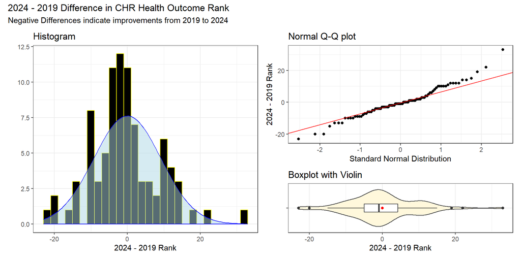

## Numerical Summary of Data

```r
ques2 |>
   reframe(lovedist(out_d))
```

```
# A tibble: 1 × 10
      n  miss  mean    sd   med   mad   min   q25   q75   max
  <int> <int> <dbl> <dbl> <dbl> <dbl> <dbl> <dbl> <dbl> <dbl>
1    88     0     0  9.21    -1  7.41   -23    -5  4.25    33
```

What can we say about the distribution of paired differences in our sample?

- Do we see meaningful skew?
- Do we see meaningfully heavy or light tails?
- Which comparison approach should we use?

## OLS/t-based approach

```r
m2a <- lm(out_d ~ 1, data = ques2)

model_parameters(m2a, conf.level = 0.95)
```

```
Parameter   | Coefficient |   SE |        95% CI |     t(87) |      p
---------------------------------------------------------------------
(Intercept) |   -4.73e-16 | 0.98 | [-1.95, 1.95] | -4.82e-16 | > .999
```

```r
m2b <- t.test(ques2$out_d, conf.level = 0.95)
model_parameters(m2b)
```

```
One Sample t-test

Parameter | Mean | mu | Difference |        95% CI | t(87) |      p
-------------------------------------------------------------------
out_d     |    0 |  0 |          0 | [-1.95, 1.95] |     0 | > .999

Alternative hypothesis: true mean is not equal to 0
```

## Bootstrap approach

```r
set.seed(432071)
boot.t.test(ques2$out_d, R = 2000, conf.level = 0.95)
```

```
    Bootstrap One Sample t-test

data:  ques2$out_d
number of bootstrap samples:  2000
bootstrap p-value = 0.951
bootstrap mean of x (SE) = -0.02305682 (0.9745855)
95 percent bootstrap percentile confidence interval:
 -1.875284  1.898011

Results without bootstrap:
t = 0, df = 87, p-value = 1
alternative hypothesis: true mean is not equal to 0
95 percent confidence interval:
 -1.952246  1.952246
sample estimates:
mean of x
        0
```

## Q2 estimates

| Approach | Estimate | 95% confidence interval |
| --- | --- | --- |
| OLS / t | 0 | (-1.95, 1.95) |
| Bootstrap | -0.02 | (-1.88, 1.90) |

- Which of these should we choose?
  - Or does it not matter much?
- Once we’ve made a choice, how can we describe the result properly?

## Choosing OLS for Paired t

- Point Estimate for mean difference = 0
- 95% confidence interval (-1.95, 1.95)

When we generalize beyond these counties to the population they were **selected at random** from, then our data are **compatible** (at the 95% confidence level) with population mean differences in rank between -1.95 and 1.95, depending on the **assumptions of our linear model** (paired t test) being correct.

# Research Question 3

## Question 3

How large is the mean difference in 2024 Health Outcomes scores across the four groups of Ohio counties defined by their 2019 Health Factors rankings?

Key variables:

- `h_out24` (numeric)
- `hfactor` (factor with 4 levels)

Comparing **Four** Means with Independent Samples

## DTDP for Question 3

What’s wrong here?

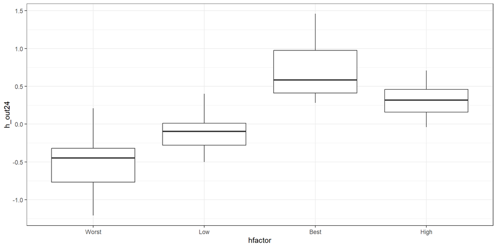

```r
ggplot(ohio_7, aes(x = hfactor, y = h_out24)) +
  geom_boxplot()
```

## Re-order `hfactor` levels

```r
ohio_7 |> tabyl(hfactor)
```

```
 hfactor  n percent
   Worst 22    0.25
     Low 22    0.25
    Best 22    0.25
    High 22    0.25
```

```r
ohio_7 <- ohio_7 |>
   mutate(hfactor = fct_relevel(hfactor,
             "Worst", "Low", "High", "Best"))

ohio_7 |> tabyl(hfactor)
```

```
 hfactor  n percent
   Worst 22    0.25
     Low 22    0.25
    High 22    0.25
    Best 22    0.25
```

## DTDP for Question 3

```r
ggplot(ohio_7, aes(x = hfactor, y = h_out24)) +
  geom_violin(aes(fill = hfactor)) +
  geom_boxplot(width = 0.2, fill = "white") +
  stat_summary(fun = mean, geom = "point",
               size = 2, col = "red") +
  scale_fill_viridis_d(option = "plasma", alpha = 0.4) +
  guides(fill = "none") +
  labs(x = "CHR 2019 Health Factors Group",
       y = "CHR 2024 Health Outcomes Score",
       title = "Four Sample Comparison")
```

## DTDP for Question 3

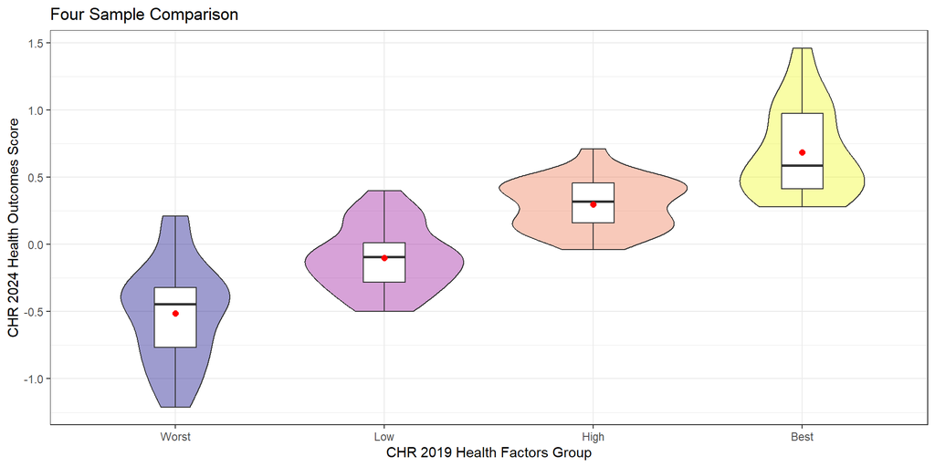

## Numerical Summary: Four Samples

```r
ohio_7 |> group_by(hfactor) |> reframe(lovedist(h_out24))
```

```
# A tibble: 4 × 11
  hfactor     n  miss   mean    sd    med   mad   min    q25     q75   max
  <fct>   <int> <int>  <dbl> <dbl>  <dbl> <dbl> <dbl>  <dbl>   <dbl> <dbl>
1 Worst      22     0 -0.513 0.376 -0.445 0.393 -1.21 -0.768 -0.32    0.21
2 Low        22     0 -0.1   0.242 -0.095 0.259 -0.5  -0.28   0.0125  0.4
3 High       22     0  0.296 0.189  0.32  0.215 -0.04  0.16   0.458   0.71
4 Best       22     0  0.683 0.334  0.585 0.289  0.28  0.412  0.975   1.46
```

- How will we analyze these data?

## ANOVA model (Comparing 4 samples)

- Our analysis will use a linear model, accompanied by an **analysis of variance (ANOVA)** table.
- We could also run an **ANOVA** table with or without pooling standard deviations.
- We’ll worry about this model only if the sample data are **very severely** non-Normal.

## ANOVA for Question 3

```r
m3 <- lm(h_out24 ~ hfactor, data = ohio_7)
anova(m3)
```

```
Analysis of Variance Table

Response: h_out24
          Df Sum Sq Mean Sq F value    Pr(>F)
hfactor    3 17.464  5.8214  67.115 < 2.2e-16 ***
Residuals 84  7.286  0.0867
---
Signif. codes:  0 '***' 0.001 '**' 0.01 '*' 0.05 '.' 0.1 ' ' 1
```

- What can we conclude here?

## Model Parameters

```r
model_parameters(m3)
```

```
Parameter      | Coefficient |   SE |         95% CI | t(84) |      p
---------------------------------------------------------------------
(Intercept)    |       -0.51 | 0.06 | [-0.64, -0.39] | -8.17 | < .001
hfactor [Low]  |        0.41 | 0.09 | [ 0.24,  0.59] |  4.65 | < .001
hfactor [High] |        0.81 | 0.09 | [ 0.63,  0.99] |  9.12 | < .001
hfactor [Best] |        1.20 | 0.09 | [ 1.02,  1.37] | 13.47 | < .001
```

- What does this suggest?

## Meaning of indicator variables?

```
h_out24 = -0.51 + 0.41 hfactor(Low)
           + 0.81 hfactor(High) + 1.20 hfactor(Best)
```

| group | `hfactorLow` | `hfactorHigh` | `hfactorBest` |
| --- | --- | --- | --- |
| Worst | 0 | 0 | 0 |
| Low | 1 | 0 | 0 |
| High | 0 | 1 | 0 |
| Best | 0 | 0 | 1 |

- So what is the predicted `h_out24` score for a county in each behavior group, according to this model?

## Calculating Estimates

```
h_out24 = -0.51 + 0.41 hfactor(Low)
           + 0.81 hfactor(High) + 1.20 hfactor(Best)
```

| Category | Predicted `h_out24` |
| --- | --- |
| Worst | -0.51 |
| Low | -0.51 + 0.41 = -0.10 |
| High | -0.51 + 0.81 = 0.30 |
| Best | -0.51 + 1.20 = 0.69 |

## Recall Observed Group Means

```r
ohio_7 |> group_by(hfactor) |>
  summarise(n = n(), mean = mean(h_out24))
```

```
# A tibble: 4 × 3
  hfactor     n   mean
  <fct>   <int>  <dbl>
1 Worst      22 -0.513
2 Low        22 -0.1
3 High       22  0.296
4 Best       22  0.683
```

Forgive the small rounding error. This matches the model, exactly.

Next time, we’ll do more.

# Research Question 4

## Question 4

How large is the mean difference in 2024 Health Outcomes scores across the three groups of Ohio counties defined by their 2019 social associations?

Key variables:

- `h_out24` (numeric)
- `soc_gp` (factor with 3 levels)

Comparing **Three** Means with Independent Samples

## DTDP for Question 4

```r
ggplot(ohio_7, aes(x = soc_gp, y = h_out24)) +
  geom_violin(aes(fill = soc_gp)) +
  geom_boxplot(width = 0.2, fill = "white") +
  stat_summary(fun = mean, geom = "point",
               size = 2, col = "red") +
  scale_fill_viridis_d(option = "plasma", alpha = 0.4) +
  guides(fill = "none") +
  labs(x = "CHR 2019 Social Associations Group",
       y = "CHR 2024 Health Outcomes Score",
       title = "Three Sample Comparison")
```

## DTDP for Question 4

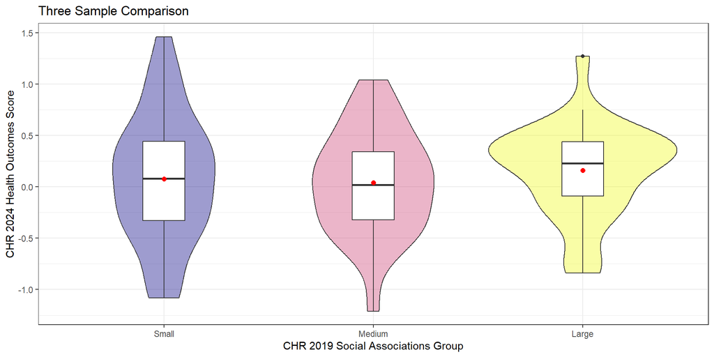

## Numerical Summary: Three Samples

```r
ohio_7 |> group_by(soc_gp) |> reframe(lovedist(h_out24))
```

```
# A tibble: 3 × 11
  soc_gp     n  miss   mean    sd   med   mad   min   q25   q75   max
  <fct>  <int> <int>  <dbl> <dbl> <dbl> <dbl> <dbl> <dbl> <dbl> <dbl>
1 Small     30     0 0.077  0.628  0.08 0.593 -1.08 -0.33 0.442  1.46
2 Medium    29     0 0.0390 0.509  0.02 0.504 -1.21 -0.32 0.34   1.04
3 Large     29     0 0.159  0.457  0.23 0.356 -0.84 -0.09 0.44   1.27
```

## ANOVA for Question 4

```r
m4 <- lm(h_out24 ~ soc_gp, data = ohio_7)
anova(m4)
```

```
Analysis of Variance Table

Response: h_out24
          Df  Sum Sq Mean Sq F value Pr(>F)
soc_gp     2  0.2183 0.10917  0.3783 0.6862
Residuals 85 24.5320 0.28861
```

- What can we conclude here?

## Model Parameters

```r
model_parameters(m4)
```

```
Parameter       | Coefficient |   SE |        95% CI | t(85) |     p
--------------------------------------------------------------------
(Intercept)     |        0.08 | 0.10 | [-0.12, 0.27] |  0.79 | 0.435
soc gp [Medium] |       -0.04 | 0.14 | [-0.32, 0.24] | -0.27 | 0.786
soc gp [Large]  |        0.08 | 0.14 | [-0.20, 0.36] |  0.59 | 0.560
```

More to come.